# CUNY DATA608 Assignment 1

Michael Ippolito

2023-02-05

```r
# Libraries
library(tidyverse)
library(psych)
library(usmap)
```

**Principles of Data Visualization and Introduction to ggplot2**

I have provided you with data about the 5,000 fastest growing companies in the US, as compiled by Inc. magazine. lets read this in:

```r
inc <- read.csv("https://raw.githubusercontent.com/charleyferrari/CUNY_DATA_608/master/module1/Data/inc5000_data.csv", header= TRUE)
```

And lets preview this data:

```r
head(inc)
```

|  | Rank | Name | Growth_Rate | Revenue | Industry | Employees | City | State |
| --- | --- | --- | --- | --- | --- | --- | --- | --- |
| 1 | 1 | Fuhu | 421.48 | 1.179e+08 | Consumer Products & Services | 104 | El Segundo | CA |
| 2 | 2 | FederalConference.com | 248.31 | 4.960e+07 | Government Services | 51 | Dumfries | VA |
| 3 | 3 | The HCI Group | 245.45 | 2.550e+07 | Health | 132 | Jacksonville | FL |
| 4 | 4 | Bridger | 233.08 | 1.900e+09 | Energy | 50 | Addison | TX |
| 5 | 5 | DataXu | 213.37 | 8.700e+07 | Advertising & Marketing | 220 | Boston | MA |
| 6 | 6 | MileStone Community Builders | 179.38 | 4.570e+07 | Real Estate | 63 | Austin | TX |

```r
NA
```

```r
summary(inc)
```

```
      Rank          Name            Growth_Rate         Revenue            Industry           Employees           City              State
 Min.   :   1   Length:5001        Min.   :  0.340   Min.   :2.000e+06   Length:5001        Min.   :    1.0   Length:5001        Length:5001
 1st Qu.:1252   Class :character   1st Qu.:  0.770   1st Qu.:5.100e+06   Class :character   1st Qu.:   25.0   Class :character   Class :character
 Median :2502   Mode  :character   Median :  1.420   Median :1.090e+07   Mode  :character   Median :   53.0   Mode  :character   Mode  :character
 Mean   :2502                      Mean   :  4.612   Mean   :4.822e+07                      Mean   :  232.7
 3rd Qu.:3751                      3rd Qu.:  3.290   3rd Qu.:2.860e+07                      3rd Qu.:  132.0
 Max.   :5000                      Max.   :421.480   Max.   :1.010e+10                      Max.   :66803.0
                                                                                            NA's   :12
```

Think a bit on what these summaries mean. Use the space below to add some more relevant non-visual exploratory information you think helps you understand this data:

```r
# Descriptive stats from psych package
describe(inc)
```

|  | vars | n | mean | sd | median | trimmed | mad | min | max | range | skew | kurtosis | se |
| --- | --- | --- | --- | --- | --- | --- | --- | --- | --- | --- | --- | --- | --- |
| Rank | 1 | 5001 | 2501.64 | 1443.51 | 2.502e+03 | 2501.73 | 1853.25 | 1.0e+00 | 5.0000e+03 | 4.9990e+03 | 0.00 | -1.20 | 20.41 |
| Name* | 2 | 5001 | 2501.00 | 1443.81 | 2.501e+03 | 2501.00 | 1853.25 | 1.0e+00 | 5.0010e+03 | 5.0000e+03 | 0.00 | -1.20 | 20.42 |
| Growth_Rate | 3 | 5001 | 4.61 | 14.12 | 1.420e+00 | 2.14 | 1.22 | 3.4e-01 | 4.2148e+02 | 4.2114e+02 | 12.55 | 242.34 | 0.20 |
| Revenue | 4 | 5001 | 48222535.49 | 240542281.14 | 1.090e+07 | 17334966.26 | 10674720.00 | 2.0e+06 | 1.0100e+10 | 1.0098e+10 | 22.17 | 722.66 | 3401441.44 |
| Industry* | 5 | 5001 | 12.10 | 7.33 | 1.300e+01 | 12.05 | 8.90 | 1.0e+00 | 2.5000e+01 | 2.4000e+01 | -0.10 | -1.18 | 0.10 |
| Employees | 6 | 4989 | 232.72 | 1353.13 | 5.300e+01 | 81.78 | 53.37 | 1.0e+00 | 6.6803e+04 | 6.6802e+04 | 29.81 | 1268.67 | 19.16 |
| City* | 7 | 5001 | 732.00 | 441.12 | 7.610e+02 | 731.74 | 604.90 | 1.0e+00 | 1.5190e+03 | 1.5180e+03 | -0.04 | -1.26 | 6.24 |
| State* | 8 | 5001 | 24.80 | 15.64 | 2.300e+01 | 24.44 | 19.27 | 1.0e+00 | 5.2000e+01 | 5.1000e+01 | 0.12 | -1.46 | 0.22 |

```r
# Factor industry
inc$Industry <- factor(inc$Industry)
summary(inc$Industry)
```

```
     Advertising & Marketing Business Products & Services            Computer Hardware                 Construction Consumer Products & Services
                         471                          482                           44                          187                          203
                   Education                       Energy                  Engineering       Environmental Services           Financial Services
                          83                          109                           74                           51                          260
             Food & Beverage          Government Services                       Health              Human Resources                    Insurance
                         131                          202                          355                          196                           50
                 IT Services   Logistics & Transportation                Manufacturing                        Media                  Real Estate
                         733                          155                          256                           54                           96
                      Retail                     Security                     Software           Telecommunications         Travel & Hospitality
                         203                           73                          342                          129                           62
```

```r
# Factor state
inc$State <- factor(inc$State)
summary(inc$State)
```

```
 AK  AL  AR  AZ  CA  CO  CT  DC  DE  FL  GA  HI  IA  ID  IL  IN  KS  KY  LA  MA  MD  ME  MI  MN  MO  MS  MT  NC  ND  NE  NH  NJ  NM  NV  NY  OH  OK  OR  PA  PR  RI  SC
  2  51   9 100 701 134  50  43  16 282 212   7  28  17 273  69  38  40  37 182 131  13 126  88  59  12   4 137  10  27  24 158   5  26 311 186  46  49 164   1  16  48
 SD  TN  TX  UT  VA  VT  WA  WI  WV  WY
  3  82 387  95 283   6 130  79   2   2
```

```r
# Bin growth rate
summary((cut(inc$Growth_Rate, breaks=10)))
```

```
(-0.0811,42.5]    (42.5,84.6]     (84.6,127]      (127,169]      (169,211]      (211,253]      (253,295]      (295,337]      (337,379]      (379,422]
          4927             49             11              5              4              4              0              0              0              1
```

```r
# Bin revenue
summary((cut(inc$Revenue, breaks=10)))
```

```
(-8.1e+06,1.01e+09] (1.01e+09,2.02e+09] (2.02e+09,3.03e+09] (3.03e+09,4.04e+09] (4.04e+09,5.05e+09] (5.05e+09,6.06e+09] (6.06e+09,7.07e+09] (7.07e+09,8.08e+09]
               4976                  15                   4                   2                   3                   0                   0                   0
(8.08e+09,9.09e+09] (9.09e+09,1.01e+10]
                  0                   1
```

```r
# Bin employees
summary((cut(inc$Employees, breaks=10)))
```

```
   (-65.8,6.68e+03] (6.68e+03,1.34e+04]    (1.34e+04,2e+04]    (2e+04,2.67e+04] (2.67e+04,3.34e+04] (3.34e+04,4.01e+04] (4.01e+04,4.68e+04] (4.68e+04,5.34e+04]
               4968                  14                   5                   0                   1                   0                   0                   0
(5.34e+04,6.01e+04] (6.01e+04,6.69e+04]                NA's
                  0                   1                  12
```

## Question 1

Create a graph that shows the distribution of companies in the dataset by State (ie how many are in each state). There are a lot of States, so consider which axis you should use. This visualization is ultimately going to be consumed on a ‘portrait’ oriented screen (ie taller than wide), which should further guide your layout choices.

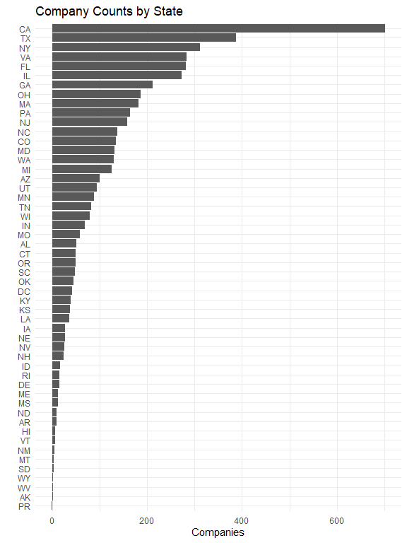

```r
# Create frequency table
dfstate <- data.frame(table(inc$State))
colnames(dfstate) <- c('state', 'freq')

# Bar plot
dfstate %>%
    ggplot(aes(x=reorder(state, freq), y=freq)) +
    geom_bar(stat='identity') +
    coord_flip() +
    theme_minimal() +
    ggtitle('Company Counts by State') +
    xlab('') + ylab('Companies')
```

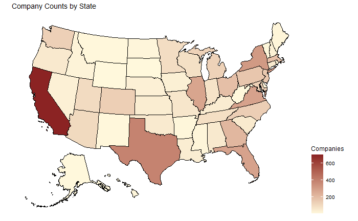

```r
# Map plot
plot_usmap(data = dfstate, values='freq') +
    scale_fill_continuous(name='Companies', label=scales::comma, low='cornsilk', high='brown4') +
    theme(legend.position='right') +
    ggtitle('Company Counts by State')
```

## Question 2

Lets dig in on the state with the 3rd most companies in the data set. Imagine you work for the state and are interested in how many people are employed by companies in different industries. Create a plot that shows the average and/or median employment by industry for companies in this state (only use cases with full data, use R’s `complete.cases()` function.) In addition to this, your graph should show how variable the ranges are, and you should deal with outliers.

Two options are shown. First, an ordinary box plot, which shows the inter-quantile range, median, and outliers, but which doesn’t show the distribution of values.

[figure not shown]

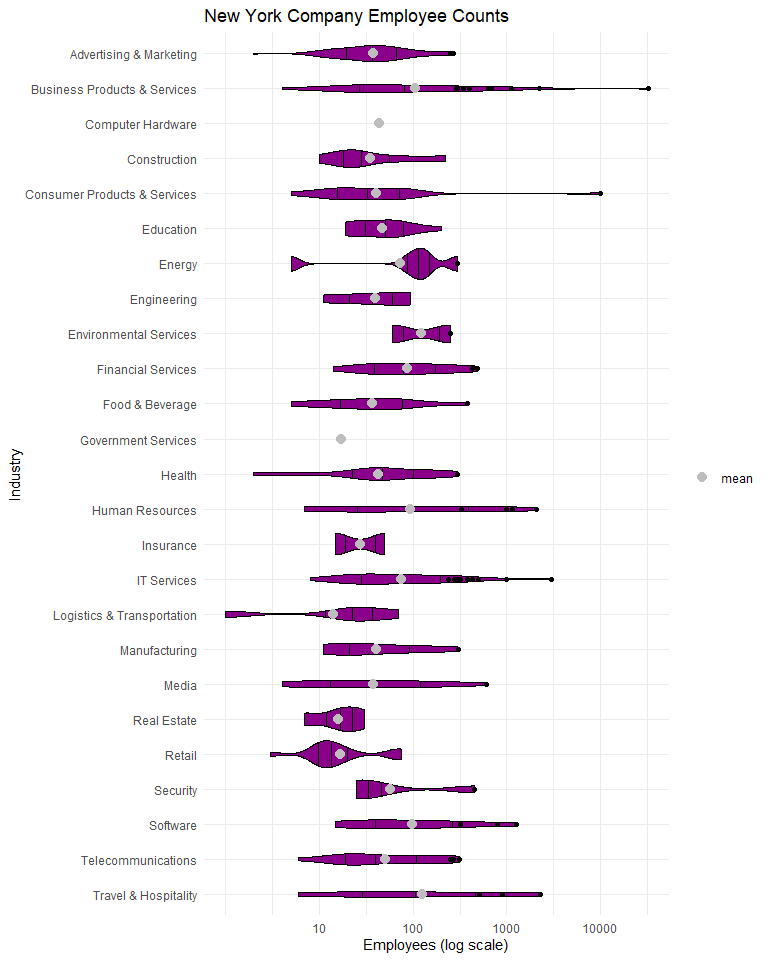

```r
# Outlier detection
out_lo <- quantile(inc_ny$Employees, probs=c(0.25)) - (1.5 * IQR(inc_ny$Employees))
out_hi <- quantile(inc_ny$Employees, probs=c(0.75)) + (1.5 * IQR(inc_ny$Employees))

# Violin plot
#inc_ny %>%
#    ggplot(aes(x='', y=Employees)) +
#    geom_violin(color='black', fill='magenta4', draw_quantiles=c(0.25, 0.5, 0.75)) +
#    geom_point(data=inc_ny[inc_ny$Employees > out_hi | inc_ny$Employees < out_lo,]) +
#    stat_summary(fun='mean', geom='point', shape=20, size=5, color='grey', fill='grey') +
#    scale_y_continuous(trans='log', breaks=c(10, 100, 1000, 10000)) +
#    theme_minimal() +
#    ggtitle('New York Company Employee Counts') +
#    ylab('Employees (log scale)') + xlab('') +
#    theme(legend.position='right') +
#    geom_point(aes(shape='mean'), alpha=0) +
#    guides(shape=guide_legend(title=NULL, override.aes=list(alpha=1, color='grey', size=5, shape=20)))

# Violin plot
inc_ny %>%
    ggplot(aes(x=reorder(Industry, desc(Industry)), y=Employees)) +
    geom_violin(color='black', fill='magenta4', draw_quantiles=c(0.25, 0.5, 0.75)) +
    geom_point(data=inc_ny[inc_ny$Employees > out_hi | inc_ny$Employees < out_lo,]) +
    stat_summary(fun='mean', geom='point', shape=20, size=5, color='grey', fill='grey') +
    scale_y_continuous(trans='log', breaks=c(10, 100, 1000, 10000)) +
    theme_minimal() +
    ggtitle('New York Company Employee Counts') +
    ylab('Employees (log scale)') + xlab('Industry') +
    theme(legend.position='right') +
    geom_point(aes(shape='mean'), alpha=0) +
    guides(shape=guide_legend(title=NULL, override.aes=list(alpha=1, color='grey', size=5, shape=20))) +
    coord_flip()
```

## Question 3

Now imagine you work for an investor and want to see which industries generate the most revenue per employee. Create a chart that makes this information clear. Once again, the distribution per industry should be shown.

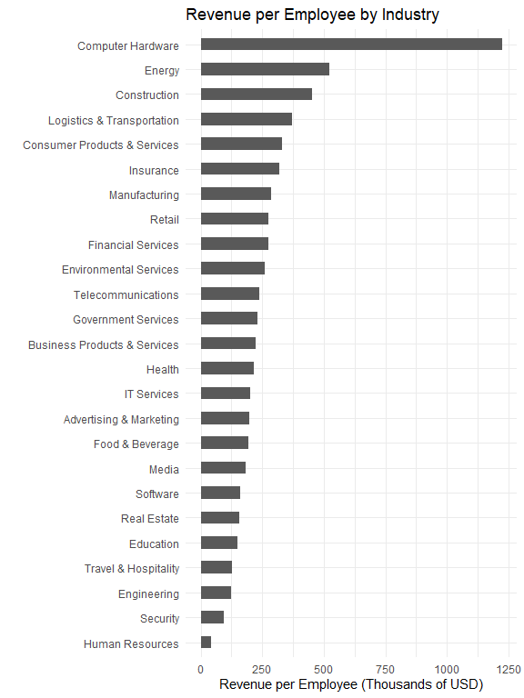

```r
# Aggregate revenue by industry and convert to billions
inc_rev <- inc[complete.cases(inc), ] %>%
    group_by(Industry) %>%
    summarise(rev=round(sum(Revenue)/sum(Employees)/1000, 1))

inc_rev %>%
    ggplot(aes(x=reorder(Industry, rev), y=rev))+
    geom_bar(stat='identity', width=0.5) +
    coord_flip() +
    theme_minimal() +
    ggtitle('Revenue per Employee by Industry') +
    xlab('') + ylab('Revenue per Employee (Thousands of USD)')
```